# GLORYS Validation

GLORYS12 is the true ocean: its velocity field moves the virtual floats and its 0–2000 m OHC is the field they sample. The ocean is held fixed. What is random is where floats are deployed: each replicate redraws the real 2010–2019 launches from a year-stratified smoothed bootstrap and advects them in GLORYS. The target is the annual mean OHC $\theta_y$ of box A (22–34$^\circ$N, gyre interior), box B (34–45$^\circ$N, Gulf Stream) and A $\cup$ B, for 2015–2019. Bias, variance and MSE are taken over 200 replicates, so they measure how the estimators behave across deployments of this one ocean. Details are in the theory note (`paper/sections/theory.tex`).

**Estimators**, per replicate and box-year:

- **naive mean**: the average OHC at the in-box float profiles;
- **mean field**: the local-polynomial mean field (Sukianto et al. 2026, eq. 5) averaged over the box;
- **map**: the mean field plus locally stationary kriging of its anomalies (Kuusela and Stein 2018), averaged over the box;
- **DR**: the map plus a $1/\hat q$-weighted mean of its residuals at held-out floats, cross-fitted over $K=5$ float folds.

The map averages over $0.5^\circ$ nodes at three times per month. Checked against the true field, that quadrature is accurate to 0.01 GJ m$^{-2}$, so all map error below is interpolation error.

# Methods

## Virtual floats

**Deployment pool.** The pool is every real Argo float launched in 2010–2019 inside the GLORYS velocity domain ($11$–$66^\circ$N, $87$–$12^\circ$W) on water at least $1000$ m deep: $994$ floats. Each keeps its launch position and date (from the GDAC metadata, or its first profile when the metadata are inconsistent) and its operating life, launch to last profile (median $1380$ d). Figure 1 shows the launch positions.

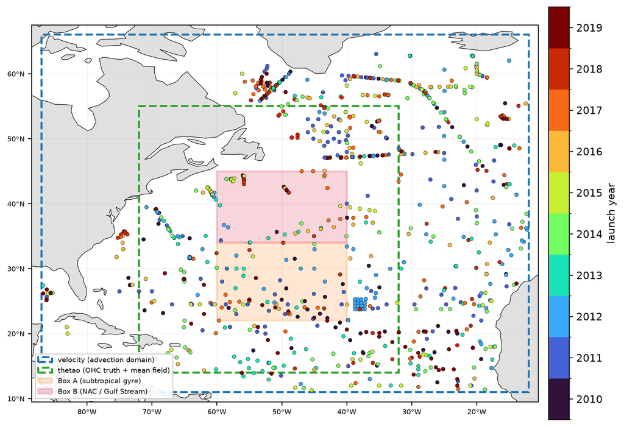

Figure 1: The deployment pool: launch positions of the 994 floats deployed in the velocity domain in 2010-2019, coloured by launch year. Blue dashed: the velocity (advection) domain; green dashed: the OHC field domain; shaded: boxes A and B.

**Resampling.** A replicate is a year-stratified smoothed bootstrap of the pool. Within each launch year $y$ it draws the year’s $N_y$ floats with replacement, so every replicate has the real yearly counts but a different set of launches. Each draw is jittered uniformly by $\pm 1/12^\circ$ in latitude and in great-circle longitude and by $\pm 10$ d in time; a jittered seed off deep water is redrawn. The $265$ floats already profiling on 2010-01-01 enter every replicate unchanged, at their first 2010 position with their remaining life. The random element of the study is this resampling, one independent draw per replicate.

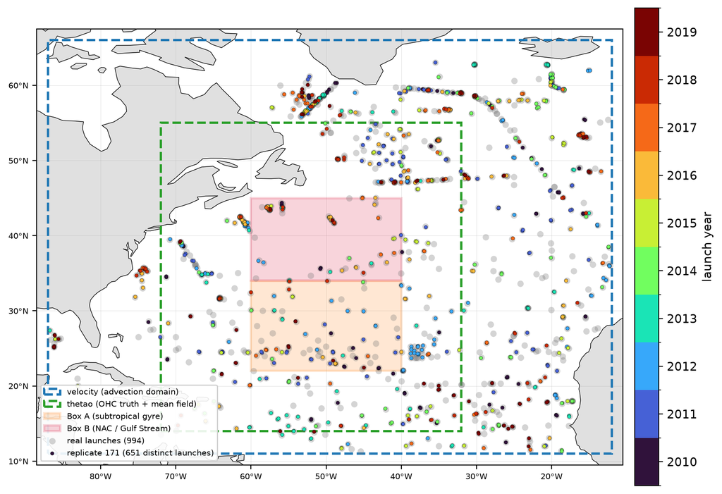

Figure 2: One bootstrap draw (replicate 171): the 994 real launch positions (grey, transparent) and the replicate’s 994 jittered seeds (solid, coloured by launch year). Sampling with replacement repeats some launches and omits others; this draw uses 651 distinct real launches.

Figure 2 shows one draw. Because it samples with replacement, some real launches appear two or more times and about a third are left out; the jitter is small at this scale, so repeated seeds sit almost on top of each other.

**Advection.** All floats of a replicate are advected together in one continuous Parcels run through the GLORYS12 daily horizontal velocity at the $1000$ m parking depth, by fourth-order Runge–Kutta with a 1 h step, from 2010-01-01 to the end of 2019. A float is removed when its life runs out or it leaves the domain. Vertical cycling is not simulated: a profile is taken every $10$ d after release at the float’s interpolated parking position. The years 2010–2014 are a spin-up, so the in-box float population is in equilibrium by the scored years 2015–2019.

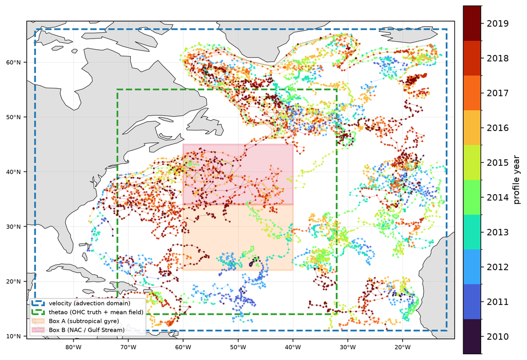

Figure 3: Replicate 171: 80 randomly chosen deployed floats, their 10-day profile positions and tracks 2010-2019, coloured by profile year. Blue dashed: the velocity (advection) domain; green dashed: the OHC field domain; shaded: boxes A and B.

**Profiles.** Each profile reads $Z$ at its containing native cell and day, with no measurement error. The map uses every profile in the buffer $14$–$55^\circ$N, $72$–$32^\circ$W, from the deployed and the initial floats. The DR weighting and the folds use only the deployed floats, whose law $\hat q$ describes. There are $1000$ replicates; $\hat q$ uses all of them, and the maps and DR are run on the first $200$. Figure 4 shows where the profiles fall in the scored years: on average $930$ profiles per year in box A and $1170$ in box B per replicate.

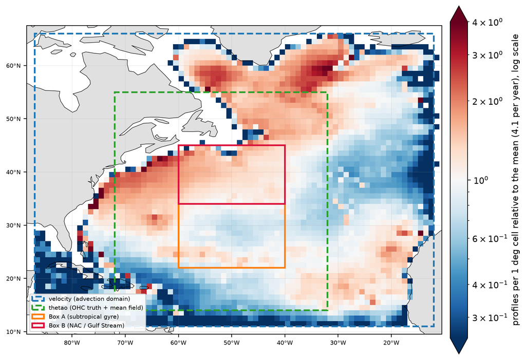

Figure 4: Deployed-float profiles in 2015-2019 per year and 1 deg cell, mean over the 1000 replicates, relative to the mean over all sampled cells (log scale from 1/4 to 4; red above, blue below the mean), over the velocity domain. Solid outlines: boxes A and B.

**Quadrature.** The target $\theta_y=\int Z\,d\mathbb P_y$ is an integral; a map is turned into a box-year mean by the quadrature rule

$$Q_y(g)=\sum_{m\in y}\frac{d_m}{D_y}\sum_{j}\frac{a_j}{\sum_{j'}a_{j'}}\cdot\frac13\sum_{l=1}^{3}g\bigl(c_j,\;t_m+\tau_l d_m\bigr),
\qquad \tau\in\{\tfrac16,\tfrac12,\tfrac56\}.$$

Here $m$ runs over the months of year $y$, with $d_m$ days, start $t_m$ and $D_y=\sum_m d_m$; $j$ runs over the box’s $0.5^\circ$ cells, with $a_j$ the area of the cell’s water deeper than $2000$ m and $c_j$ its area centroid. So $Q_y$ is an area-weighted mean over cells at three times per month, and the months are day-weighted. The map and fold-map estimates are $Q_y(\hat m)$ and $Q_y(\hat m_{-k})$. Applied to the true field, $Q_y(Z)$ differs from $\theta_y$ by at most $0.01$ GJ m$^{-2}$, so the quadrature remainder $\theta_y-Q_y(Z)$ is negligible next to every error below.

## Sampling intensity: $q$, $\hat q$ and $w$

Let $\nu$ be area $\times$ time measure on the deep ocean of a box-year $S_y$ and $\mathbb P_y=\nu/\nu(S_y)$ its normalized version, so $\theta_y=\int Z\,d\mathbb P_y$. One deployment produces a random set of in-box profile locations $\{s_i\}$, a point process $N$ on $S_y$. Its intensity measure $\Lambda(B)=\mathbb E\,N(B)$, the expected number of profiles in $B$ over deployments, is absolutely continuous with respect to $\nu$, and

$$q=\frac{d\Lambda}{d\nu}$$

is the **sampling intensity**: expected profiles per m$^2$ per day at each place and time. It describes the deployment law, not one array. A single replicate is one noisy draw from it. Campbell’s theorem, $\mathbb E\sum_i g(s_i)=\int g\,q\,d\nu$, is what makes $1/q$ the right weight. Wherever $q>0$, $\mathbb E\sum_i g(s_i)/q(s_i)=\int g\,d\nu$, whatever the sampling pattern.

The **normalized intensity** $w=q/\bar q_y$, with $\bar q_y=\int q\,d\mathbb P_y$, is the density of the profile locations relative to uniform sampling. $w=2$ means twice as many profiles as an even spread would give, and $w=1/2$ half as many. The naive mean averages $Z$ under $w\,d\mathbb P_y$ instead of $d\mathbb P_y$. Since $\int w\,d\mathbb P_y=1$,

$$\int wZ\,d\mathbb P_y-\theta_y=\operatorname{Cov}_{\mathbb P_y}(w,Z),$$

so floats over-sampling cold water ($w$ and $Z$ negatively correlated) make it too cold. This is preferential sampling in the design sense.

$q$ is unknown, so it is estimated from the simulated deployments. For launch-year cohort $c$ with $N_c$ floats per replicate,

$$\hat q^{(1)}_c(s)=\frac{\sum_{r}\sum_{i\in c,\,r}k_h(s-s_{ri})}{R\,N_c\int_{S}k_h(s-u)\,\nu(du)},
\qquad
\hat q=\sum_c N_c\,\hat q^{(1)}_c,$$

where the sum runs over the cohort’s profiles in the $R=1000$ replicates and $k_h$ is a Gaussian kernel with sd $1/6^\circ$ in latitude and longitude and $2$ d in time, truncated at $4$ sd. The denominator is the kernel mass on the ocean support $S$, which corrects for coasts and shelf. $\hat q^{(1)}_c$ is the intensity of one cohort-$c$ float, so a fold of $n_{k,c}$ cohort-$c$ floats has intensity $\hat q_k=\sum_c n_{k,c}\hat q^{(1)}_c$. When $\hat q$ weights a replicate’s own profiles, that replicate is left out ($R-1$ in the denominator). The plug-in $\hat w=\hat q/\int\hat q\,d\mathbb P_y$ is what the maps below show.

## Mean field

Following Sukianto et al. (2026) (their eq. 5), which extends Ridgway et al. (2002) and Roemmich and Gilson (2009) with linear and quadratic time trends, the mean field is a local polynomial regression in a fixed square window $\mathcal W(x^*, y^*) = [x^* \pm \lambda] \times [y^* \pm \lambda]$, $\lambda = 5^\circ$, around each centre $(x^*, y^*)$ of a $1^\circ$ grid. It uses all of the replicate’s 2010–2019 profiles in the window:

$$\begin{aligned}
m_{x^*, y^*}(x, y, t) = {}& \beta_0 + \beta_1 (x - x^*) + \beta_2 (y - y^*) + \beta_3 (x - x^*)(y - y^*)
+ \beta_4 (x - x^*)^2 + \beta_5 (y - y^*)^2 \\
&+ \sum_{k=1}^{6} \Bigl[\gamma_k \sin\tfrac{2\pi k \tau(t)}{365} + \delta_k \cos\tfrac{2\pi k \tau(t)}{365}\Bigr]
+ \nu_1 (t - t_D) + \nu_2 (t - t_D)^2,
\end{aligned}$$

with $\tau(t)$ the yearday and $t_D$ = 2015-01-01. The coefficients are least squares over the window’s profiles, with a ridge of $10^{-8}\operatorname{tr}G$ on the Gram matrix $G$ for numerical stability. The window is never widened: a centre with fewer than 60 profiles (three per coefficient) is left unfitted. The fit at the centre is

$$\hat\mu(x^*, y^*, t) = \hat\beta_0 + \sum_{k=1}^{6} \Bigl[\hat\gamma_k \sin\tfrac{2\pi k \tau(t)}{365}
+ \hat\delta_k \cos\tfrac{2\pi k \tau(t)}{365}\Bigr] + \hat\nu_1 (t - t_D) + \hat\nu_2 (t - t_D)^2 .$$

Off the grid, $\hat\mu(x, y, t)$ interpolates the four surrounding centres bilinearly, renormalized over the fitted ones. This is our choice: Sukianto et al. (2026) define $\hat\mu$ only at the grid points. For DR, $\hat\mu_{-k}$ refits every window without fold $k$’s floats. The refit is exact, by subtracting that fold’s contribution to each window’s normal equations.

Figure 5 compares the mean field with the truth month by month.

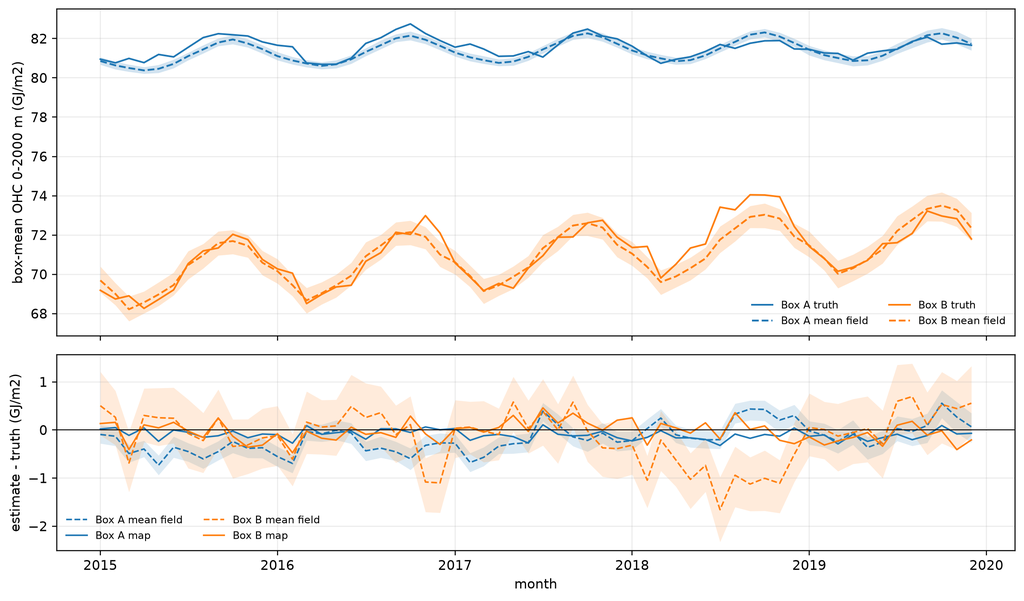

Figure 5: Top: monthly true box-mean OHC (solid) and the mean field (dashed; median over 200 replicates, band 5-95%). Bottom: mean-field error (dashed, with band) and map error (solid), medians over replicates (GJ per m2).

The mean field follows the seasonal cycle and the decade-long warming. What it leaves is interannual and persistent: in box B the typical monthly error runs from $-1.7$ to $+0.7$ GJ m$^{-2}$, and in box A from $-0.7$ to $+0.6$. Kriging the anomalies removes much of this, and the remainder is the map’s bias.

## Kriging

The anomaly $Z - \hat\mu$ is modelled as a zero-mean Gaussian process with the locally stationary anisotropic exponential covariance of Kuusela and Stein (2018):

$$k\bigl((x, y, t), (x', y', t')\bigr) = \phi \exp(-d) + \sigma^2 \mathbf 1\{\text{same point}\},
\qquad
d^2 = \Bigl(\tfrac{x - x'}{\theta_{\text{lon}}}\Bigr)^2 + \Bigl(\tfrac{y - y'}{\theta_{\text{lat}}}\Bigr)^2
+ \Bigl(\tfrac{t - t'}{\theta_t}\Bigr)^2,$$

with $(\phi, \theta_{\text{lon}}, \theta_{\text{lat}}, \theta_t, \sigma^2/\phi)$ fixed per $2^\circ$ cell. The parameters are fitted once, by windowed maximum likelihood with years as replicates and the median over months. The fit uses GLORYS OHC minus the mean field from the real Argo positions, on the complete $1^\circ\times10$ d lattice of 2015–2019. They are therefore external to every replicate. They are also **oracle** values: no real analysis sees the full field.

|  | $\phi$ | $\theta_{\text{lon}}$ | $\theta_{\text{lat}}$ | $\theta_t$ |
| --- | --- | --- | --- | --- |
| Box A (median over cells) | 19.4 | 3.5° | 2.9° | 83 d |
| Box B (median over cells) | 48.9 | 2.4° | 1.5° | 38 d |

Prediction is simple kriging in continuous time. A target in cell $c$ conditions on all of the replicate’s profiles within $\pm 10^\circ$ and $\pm 180$ d and uses cell $c$’s parameters. The map is $\hat m = \hat\mu + \hat\eta$. The fold map $\hat m_{-k} = \hat\mu_{-k} + \hat\eta_{-k}$ drops fold $k$’s floats from both stages. The kriging drop is exact, by block downdates of the conditioning system.

## Cross-fit DR

The deployed floats are split into $K = 5$ folds by a random permutation within each launch-year cohort, so every fold carries about a fifth of each cohort. For fold $k$, $I_k$ is the set of its floats’ in-box profiles in year $y$, with residuals $e_k(x_i) = Z_i - \hat m_{-k}(x_i)$ against the map fitted without them. Then

$$\hat\theta_{\mathrm{DR}} = \frac1K\sum_{k=1}^K\Bigl\{Q_y(\hat m_{-k}) + \hat C_k\Bigr\},
\qquad
\hat C_k = \frac{\sum_{i\in I_k} v_i\,e_k(x_i)}{\sum_{i\in I_k} v_i},
\qquad
v_i = \frac{1}{\hat q_k(x_i)} .$$

$\hat q_k$ is fold $k$’s intensity from above, computed without the evaluated replicate. This keeps the weights independent of the floats they weight, which the unbiasedness argument (Campbell’s theorem) requires. $Q_y(\hat m_{-k})$ is fold $k$’s map estimate, and

$$T_k=\theta_y-Q_y(\hat m_{-k})$$

is what it misses: the error of the map fitted without fold $k$, with the sign of a correction. $\hat C_k$, a $1/\hat q_k$-weighted (Hájek) mean of fold $k$’s residuals, estimates $T_k$. In practice $T_k$ is unknown because $\theta_y$ is; here the truth is known, so $T_k$ can be computed and every correction checked against its target. Subtracting $\theta_y$ from the estimator gives the exact identity

$$\hat\theta_{\mathrm{DR}}-\theta_y=\frac1K\sum_{k=1}^K\bigl(\hat C_k-T_k\bigr),$$

so DR’s error is the average error of the five corrections, and DR is unbiased exactly when the corrections are unbiased for their targets on average.

# Sampling intensity

Floats are up to three times more dense than average in some places and under half as dense in others. In box B the dense and sparse regions line up with the OHC gradient across the Gulf Stream.

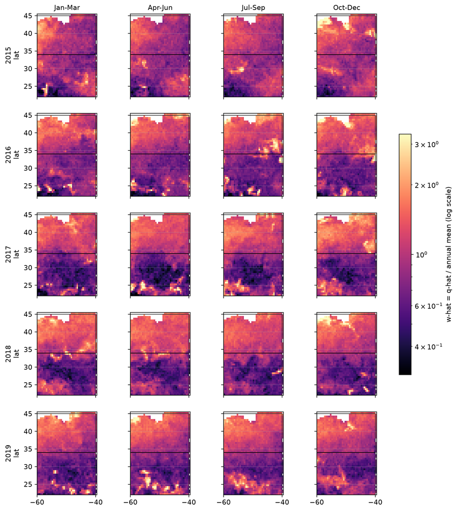

Figure 6: Quarterly-mean sampling intensity q-hat of the full deployment law relative to its annual mean over A u B (log scale, common colour scale), 2015-2019.

Figure 6 shows $\hat q$ by quarter. The pattern is stable within and across years: box B is sampled more densely than box A throughout (median $\hat w$ of $1.23$ vs $0.71$ over quarters), and the quarterly 5–95% range of $\hat w$ in box B ($0.79$–$1.88$) is only slightly wider than the annual one ($0.84$–$1.77$).

# Preferential sampling

The naive mean’s expected bias is $\operatorname{Cov}_{\mathbb P_y}(w,Z)$ (Methods): how strongly the sampling intensity lines up with OHC. Figure 7 compares the naive bias, averaged over 1000 replicates, with this covariance computed from the kernel estimate $\hat w$ and the true field alone, without using any replicate’s naive mean.

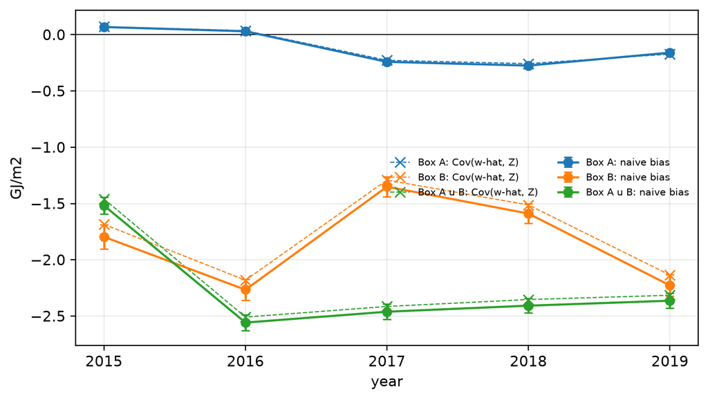

Figure 7: Naive bias (estimate minus truth, mean over 1000 replicates, +/- 2 Monte Carlo se) and the alignment Cov(w-hat, Z) of the kernel sampling intensity with OHC (GJ per m2).

Floats under-sample warm water. The naive mean is 1.3–2.6 GJ m$^{-2}$ too cold in box B and A $\cup$ B, and the covariance accounts for $94$–$98\%$ of it; the small remainder is smoothing in $\hat w$.

# Bias–variance trade-off

**Box A**

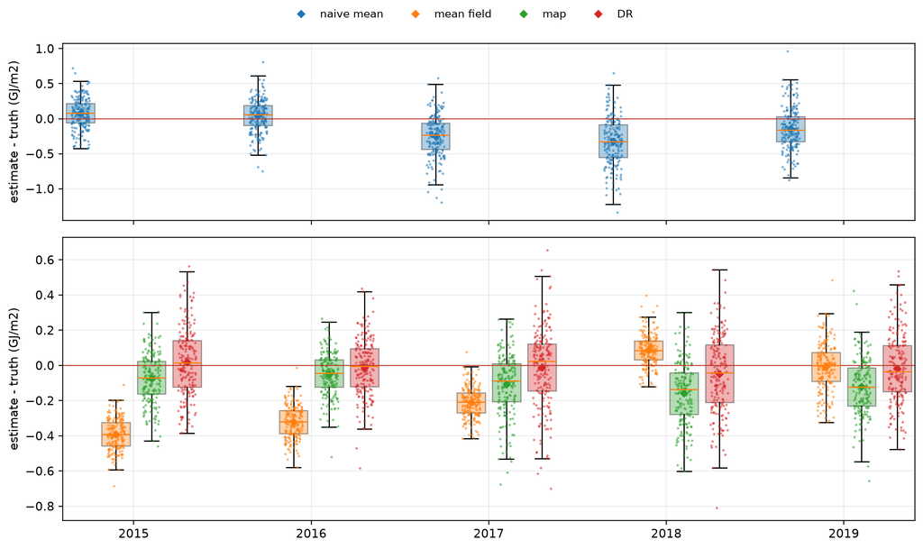

**Box B**

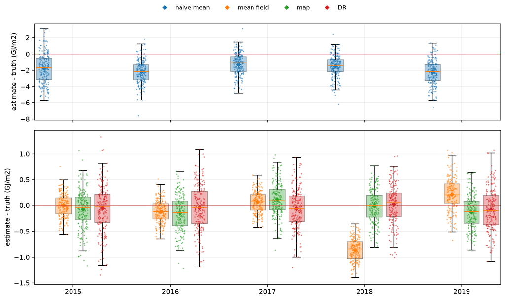

**Box A u B**

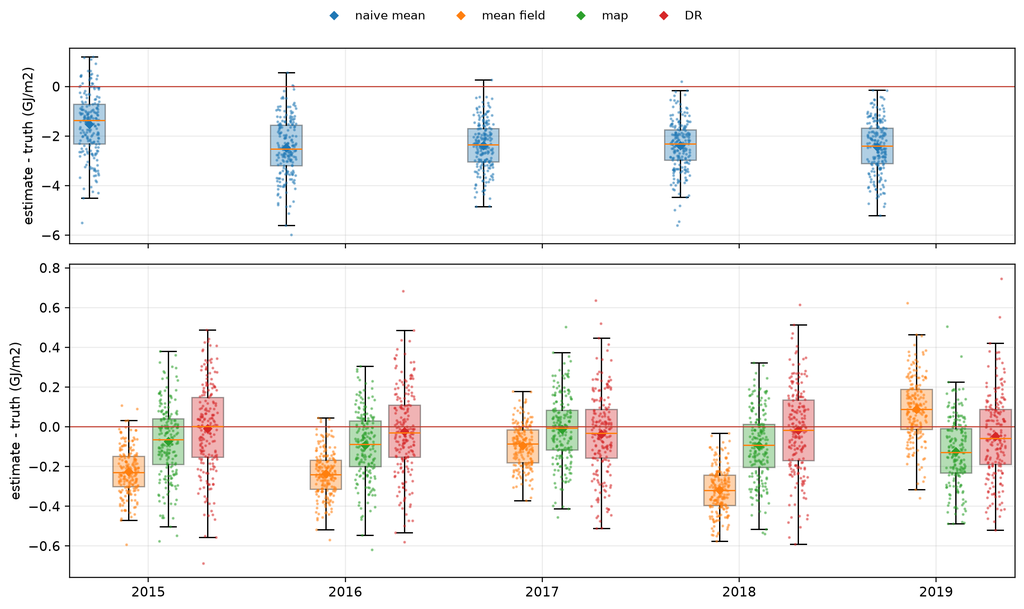

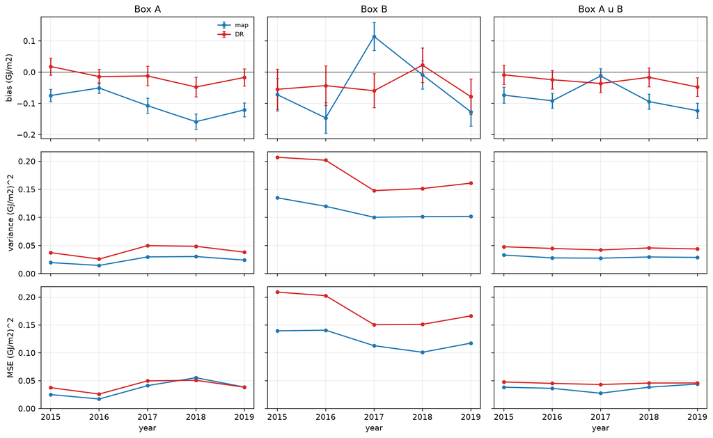

Figure 8: Bias (+/- 2 Monte Carlo se, GJ per m2), variance and MSE ((GJ per m2) squared) of the map and DR by year over 200 replicates.

The map’s bias in box A is negative in every year and largest in 2018 ($-0.16$). DR’s MSE exceeds the map’s except in box A 2018–2019, where they tie. In box B the map’s bias changes sign from year to year, and the variance of the DR correction dominates there.

# DR reweighting of kriging residuals

The map fitted without fold $k$ misses the truth by $T_k=\theta_y-Q_y(\hat m_{-k})$. DR estimates $T_k$ from the fold-$k$ floats’ residuals $e_k=Z-\hat m_{-k}$. Floats crowd where $q$ is large, so a plain average of the residuals is tilted the same way as the naive mean. Weighting by $1/\hat q_k$ removes the tilt. Figure 9 shows one replicate-year, picked for its large map error (box B 2017, replicate 171: map $+0.45$, DR $-0.02$ GJ m$^{-2}$).

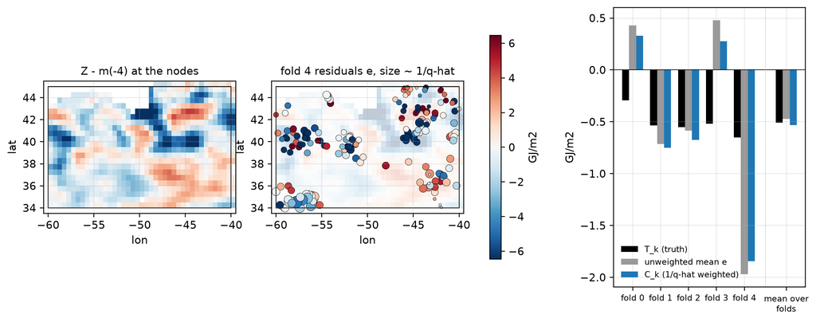

Figure 9: Replicate 171, box B, 2017. Left: error field of the map fitted without fold k. Middle: fold k’s residuals at its floats’ profiles, marker area proportional to the weight 1/q-hat. Right: per fold and averaged over folds, the target T_k, the plain residual mean and the weighted correction C_k (GJ per m2).

In the right panel each fold is one estimation problem. The black bar $T_k$ is what fold $k$’s map misses, the target. The blue bar $\hat C_k$ is DR’s estimate of it, and the grey bar is the same residuals averaged without weights. A good correction has its blue bar close to the black one. Single folds are noisy (two of five here correct in the wrong direction). What enters the estimator is the average over folds, the right-most group: DR’s error is the gap between the averaged blue and black bars, here $-0.53$ against $-0.51$.

# Summary

- Floats preferentially sample cold water; the naive mean is biased by up to $-2.5$ GJ m$^{-2}$.
- The map is the most precise annual estimator, but keeps a persistent bias of $-0.1$ GJ m$^{-2}$ in box A.
- DR removes most of that bias at the price of more variance, and for single years the added variance outweighs the bias removed in every box.
- DR’s remaining bias is kernel smoothing in $\hat q$, which narrower kernels or more replicates could reduce.

## References

Kuusela, Mikael, and Michael L. Stein. 2018. “Locally Stationary Spatio-Temporal Interpolation of Argo Profiling Float Data.” *Proceedings of the Royal Society A* 474 (2220): 20180400. https://doi.org/10.1098/rspa.2018.0400.

Ridgway, K. R., J. R. Dunn, and J. L. Wilkin. 2002. “Ocean Interpolation by Four-Dimensional Weighted Least Squares—Application to the Waters Around Australia.” *Journal of Atmospheric and Oceanic Technology* 19 (9): 1357–75. https://doi.org/10.1175/1520-0426(2002)019<1357:OIBFDW>2.0.CO;2.

Roemmich, Dean, and John Gilson. 2009. “The 2004–2008 Mean and Annual Cycle of Temperature, Salinity, and Steric Height in the Global Ocean from the Argo Program.” *Progress in Oceanography* 82 (2): 81–100. https://doi.org/10.1016/j.pocean.2009.03.004.

Sukianto, Thea, Mikael Kuusela, Donata Giglio, Anirban Mondal, Pulong Ma, and Douglas W. Nychka. 2026. *Locally Stationary Argo Ocean Heat Content Estimates: Modeling, Validation and Uncertainty Quantification*. https://arxiv.org/abs/2606.31957.